# DATS 6101 Project 1

Tyler Wallett, Anushka Vuppala and David Li

2022-11-02

2022-11-03

# Introduction

Our research topic aims to perform explorartory data analysis on the Nearest Earth Objects (NEO) dataset recorded by NASA. This particular dataset includes thousands of labeled observations, over the last 22 years, across multiple attributes that each aim to describe a specific object. Borrowing from the humor of the recent film *Don’t Look Up* by Adam Mckay and NASA’s success in the Double Asteroid Redirection Test (DART) mission, we thought that further describing and exploring this dataset would be opportune.

This EDA that we do can help with the early detection of an asteroid. With the early detection, NASA can take quick remedies to help eliminate the threat. NASA’s DART mission (Double Asteroid Redirection Test) was done for the same purpose. It was designed to deflect an asteroid with a certain momentum by hitting it head-on or attempting to slow it down. More can be read online from this [article](https://en.wikipedia.org/wiki/Double_Asteroid_Redirection_Test)

According to NASA’s [official documentation](https://cneos.jpl.nasa.gov/about/neo_groups.html) on PHAs, a PHA is technically termed using parameters that measure the asteroid’s characteristics and then make a decision if the asteroid is considered hazardous based on certain thresholds. Specifically, all asteroids with an Earth Minimum Orbit intersection Distance (MOID) of 0.05 au or less and an absolute magnitude (H) of 22.0 or less are considered Potentially Hazardous Asteroids (PHAs). In other words, asteroids that can’t get any closer to the Earth (i.e., MOID) than 0.05 au (roughly 7,480,000km) or are smaller than about 140m in diameter (i.e., H=22.0) are not considered PHAs.

The current dataset that we have contains 90,000 rows. Each row represents a NEO identified by an ID and name. Out of these 90,000 rows, 9,000 of them are hazardous and 81,000 of them are non-hazardous. This dataset does not contain null values. Apart from the hazardous target variable, our dataset contains 5 numerical variables that can help identify if the asteroid is hazardous or not. These 5 variables are:

1. est_diameter_min (km) – estimated minimum diameter of the NEO
2. est_diameter_max (km) – estimated maximum diameter of the NEO
3. relative_velocity – the velocity (in km/seconds) with which the NEO was travelling with respect to Earth
4. miss_distance – distance (in km) by which the asteroid missed the Earth’s surface
5. absolute_magnitude (H) – signifies the brightness of the asteroid

Out of these 5 variables, we have 3 variables that play a primary role in determining if the asteroid was harmful or not. Those are:

1. relative_velocity
2. miss_distance
3. absolute_magnitude

Throughout the rest of this RMD file, we go over each of these 3 variables in complete depth to answer our SMART question – what are some of the statistical characteristics of Nearest Earth Objects, over the last 22 years, in terms of relative velocity, miss distance and absolute magnitude, that make them hazardous or not?

# Let’s explore the dataset

Displaying the structure of the data:

```
## 'data.frame':    90836 obs. of  10 variables:
##  $ id                : int  2162635 2277475 2512244 3596030 3667127 54138696 54189957 54230078 2088213 3766065 ...
##  $ name              : chr  "162635 (2000 SS164)" "277475 (2005 WK4)" "512244 (2015 YE18)" "(2012 BV13)" ...
##  $ est_diameter_min  : num  1.1983 0.2658 0.722 0.0965 0.255 ...
##  $ est_diameter_max  : num  2.679 0.594 1.615 0.216 0.57 ...
##  $ relative_velocity : num  13569 73589 114259 24764 42738 ...
##  $ miss_distance     : num  54839744 61438127 49798725 25434973 46275567 ...
##  $ orbiting_body     : chr  "Earth" "Earth" "Earth" "Earth" ...
##  $ sentry_object     : chr  "False" "False" "False" "False" ...
##  $ absolute_magnitude: num  16.7 20 17.8 22.2 20.1 ...
##  $ hazardous         : chr  "False" "True" "False" "False" ...
## NULL
```

Displaying the first 6 rows of the dataset:

```
##         id                name est_diameter_min est_diameter_max
## 1  2162635 162635 (2000 SS164)           1.1983           2.6794
## 2  2277475   277475 (2005 WK4)           0.2658           0.5943
## 3  2512244  512244 (2015 YE18)           0.7220           1.6145
## 4  3596030         (2012 BV13)           0.0965           0.2158
## 5  3667127         (2014 GE35)           0.2550           0.5702
## 6 54138696         (2021 GY23)           0.0364           0.0813
##   relative_velocity miss_distance orbiting_body sentry_object
## 1             13569      54839744         Earth         False
## 2             73589      61438127         Earth         False
## 3            114259      49798725         Earth         False
## 4             24764      25434973         Earth         False
## 5             42738      46275567         Earth         False
## 6             34298      40585691         Earth         False
##   absolute_magnitude hazardous
## 1               16.7     False
## 2               20.0      True
## 3               17.8     False
## 4               22.2     False
## 5               20.1      True
## 6               24.3     False
```

The number of NA values in the dataset => 0

Now, we split the dataset into 2 dataframes - one for hazardous and other for non-hazardous. This is to ease out the tests performed.

The dimensions of hazardous asteroids dataframe: 8840, 10

The dimensions of non_hazardous asteroids dataframe: 81996, 10

# Performing measures of central tendency using Summary

Summary of all asteroids is as follows:

```
##        id               name           est_diameter_min est_diameter_max
##  Min.   : 2000433   Length:90836       Min.   : 0.0     Min.   : 0.0
##  1st Qu.: 3448110   Class :character   1st Qu.: 0.0     1st Qu.: 0.0
##  Median : 3748362   Mode  :character   Median : 0.0     Median : 0.1
##  Mean   :14382878                      Mean   : 0.1     Mean   : 0.3
##  3rd Qu.: 3884023                      3rd Qu.: 0.1     3rd Qu.: 0.3
##  Max.   :54275914                      Max.   :37.9     Max.   :84.7
##  relative_velocity miss_distance      orbiting_body      sentry_object
##  Min.   :   203    Min.   :    6746   Length:90836       Length:90836
##  1st Qu.: 28619    1st Qu.:17210820   Class :character   Class :character
##  Median : 44190    Median :37846579   Mode  :character   Mode  :character
##  Mean   : 48067    Mean   :37066546
##  3rd Qu.: 62924    3rd Qu.:56548996
##  Max.   :236990    Max.   :74798651
##  absolute_magnitude  hazardous
##  Min.   : 9.2       Length:90836
##  1st Qu.:21.3       Class :character
##  Median :23.7       Mode  :character
##  Mean   :23.5
##  3rd Qu.:25.7
##  Max.   :33.2
```

# Distinct Values

Now, there are multiple asteroids with the same “id” and “name” in the dataset. This could happen due to multiple tests being performed on the asteroids or it could be another different reason. We shall remove these in order for the dataset to follow the rules of a relational dataset. We use the group_by function provided in R to do so and we take the mean of those asteroids with the same id and name so we don’t have any risk of losing the data.

The dimension of the hazardous dataframe after using only distinct asteroid ID’s => 2173, 5

The dimension of the non_hazardous dataframe after using only distinct asteroid ID’s => 25250, 5

# Relative Velocity

Relative velocity of an NEO is defined as its velocity compared to the earth. It is measured in kilometers per second.

```r
library(tidyverse)
neo <- read.csv("neo.csv")
hazardous = neo %>% filter(hazardous=="True")
safe = neo %>% filter(hazardous=="False")
xkablesummary(hazardous[c("relative_velocity")])
```

Table: Statistics summary.

|  | relative_velocity |
| --- | --- |
| Min | Min. : 5908 |
| Q1 | 1st Qu.: 43018 |
| Median | Median : 58658 |
| Mean | Mean : 62794 |
| Q3 | 3rd Qu.: 78786 |
| Max | Max. :193387 |

```r
xkablesummary(safe[c("relative_velocity")])
```

Table: Statistics summary.

|  | relative_velocity |
| --- | --- |
| Min | Min. : 203 |
| Q1 | 1st Qu.: 27636 |
| Median | Median : 42566 |
| Mean | Mean : 46479 |
| Q3 | 3rd Qu.: 61062 |
| Max | Max. :236990 |

```r
ttest2sample_neo = t.test(hazardous$relative_velocity,safe$relative_velocity)
ttest2sample_neo
```

```
##
##  Welch Two Sample t-test
##
## data:  hazardous$relative_velocity and safe$relative_velocity
## t = 54, df = 10456, p-value <2e-16
## alternative hypothesis: true difference in means is not equal to 0
## 95 percent confidence interval:
##  15724 16906
## sample estimates:
## mean of x mean of y
##     62794     46479
```

```r
ttestsafe95 = t.test(x=safe$relative_velocity, conf.level = .95)
ttestsafe99 = t.test(x=safe$relative_velocity, conf.level = .99)
ttestsafe95$conf.int
```

```
## [1] 46311 46647
## attr(,"conf.level")
## [1] 0.95
```

```r
ttestsafe99$conf.int
```

```
## [1] 46258 46700
## attr(,"conf.level")
## [1] 0.99
```

```r
ttesthaz95 = t.test(x=hazardous$relative_velocity, conf.level = .95)
ttesthaz99 = t.test(x=hazardous$relative_velocity, conf.level = .99)
ttesthaz95$conf.int
```

```
## [1] 62228 63361
## attr(,"conf.level")
## [1] 0.95
```

```r
ttesthaz99$conf.int
```

```
## [1] 62050 63539
## attr(,"conf.level")
## [1] 0.99
```

```r
anovavelocity = aov(formula = relative_velocity ~ hazardous, data = neo)
xkabledply(anovavelocity)
```

Model: relative_velocity ~ hazardous

|  | Df | Sum Sq | Mean Sq | F value | Pr(>F) |
| --- | --- | --- | --- | --- | --- |
| hazardous | 1 | 2.12e+12 | 2.12e+12 | 3446 | 0 |
| Residuals | 90834 | 5.60e+13 | 6.16e+08 | NA | NA |

```r
tukeyvelocity <- TukeyHSD(anovavelocity)
tukeyvelocity
```

```
##   Tukey multiple comparisons of means
##     95% family-wise confidence level
##
## Fit: aov(formula = relative_velocity ~ hazardous, data = neo)
##
## $hazardous
##             diff   lwr   upr p adj
## True-False 16315 15770 16860     0
```

```r
plot(tukeyvelocity, las=1 , col="brown", title = "TUKEY Multiple Comparison of Means for Relative Velocity")
```

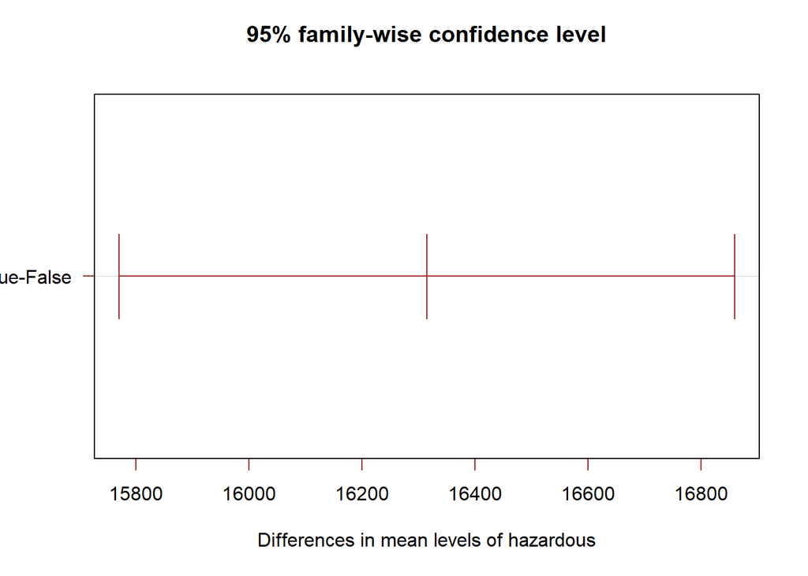

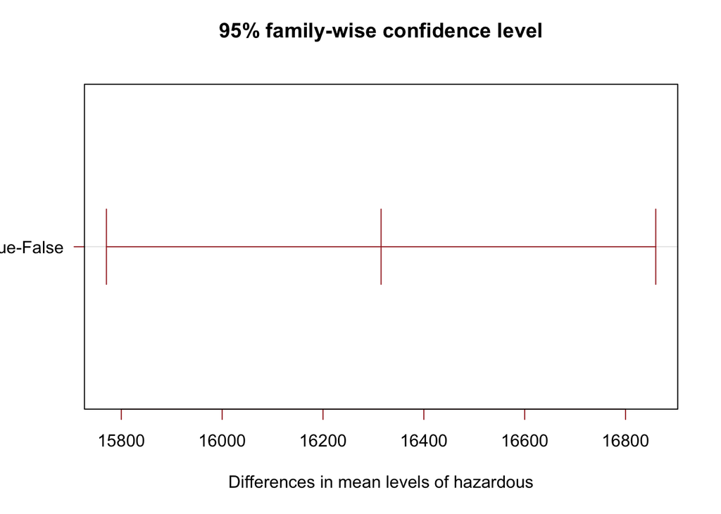

For basic descriptive statistics, measures of central tendency, mean and median, are all higher in the “hazardous” group compared to the objects deemed “safe.”

Using a 2-sample T-Test shows that the difference in means in two groups are significant at the 95% confidence level, as the P-value is smaller than .05.

```r
qqnorm(hazardous$relative_velocity, col='red', main = 'QQ Plot for Velocity of Hazardous Objects')
qqline(hazardous$relative_velocity)
```

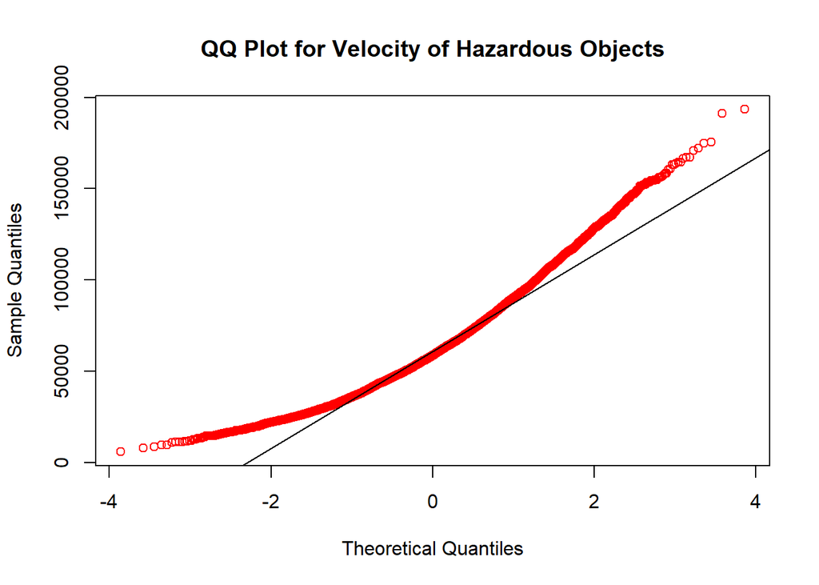

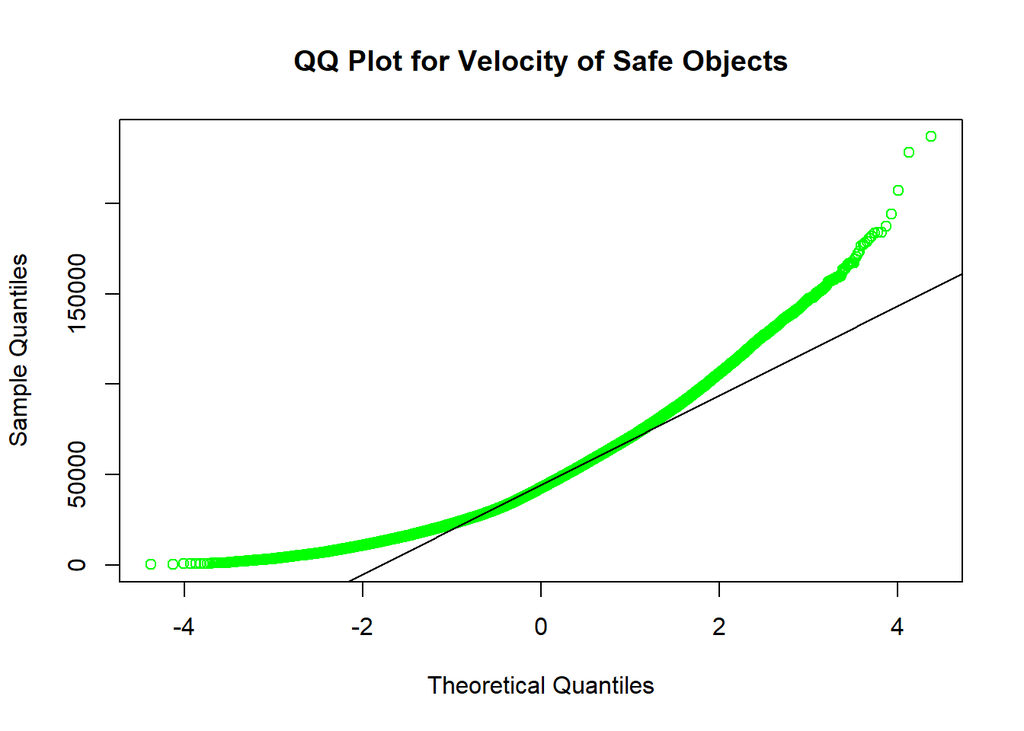

```r
qqnorm(safe$relative_velocity, col='green', main = 'QQ Plot for Velocity of Safe Objects')
qqline(safe$relative_velocity)
```

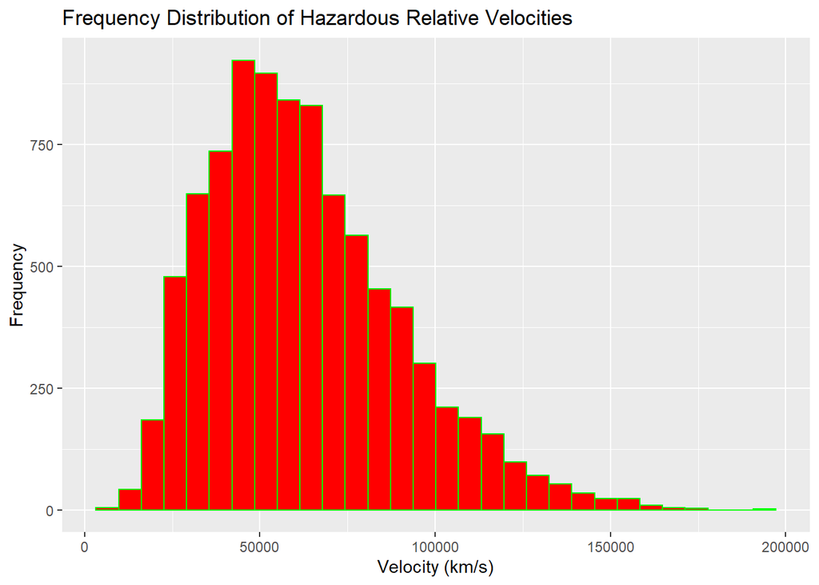

```r
ggplot(data=hazardous, aes(relative_velocity)) + geom_histogram(col='green',fill="red")+labs(x= "Velocity (km/s)", y="Frequency") + labs(title="Frequency Distribution of Hazardous Relative Velocities")
```

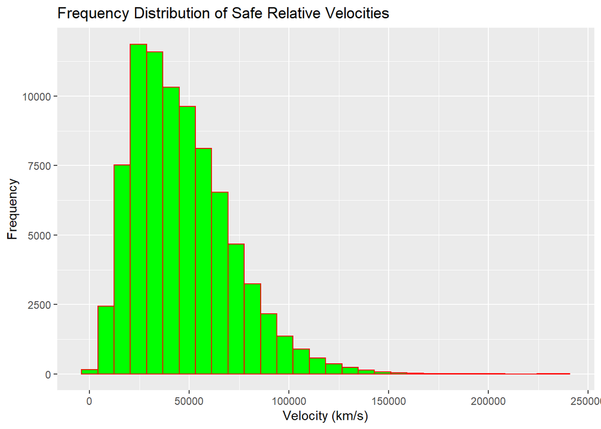

```r
ggplot(data=safe, aes(relative_velocity)) + geom_histogram(col='red',fill="green")+labs(x= "Velocity (km/s)", y="Frequency") + labs(title="Frequency Distribution of Safe Relative Velocities")
```

[figure not shown]

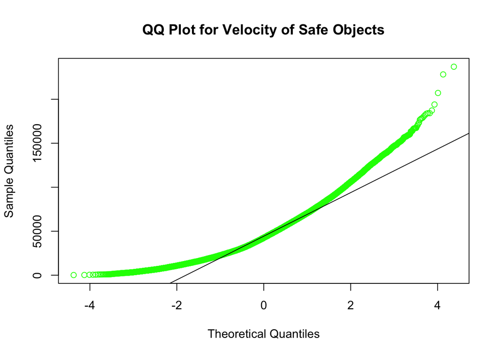

```r
qqnorm(safe$relative_velocity, col='green', main = 'QQ Plot for Velocity of Safe Objects')
qqline(safe$relative_velocity)
```

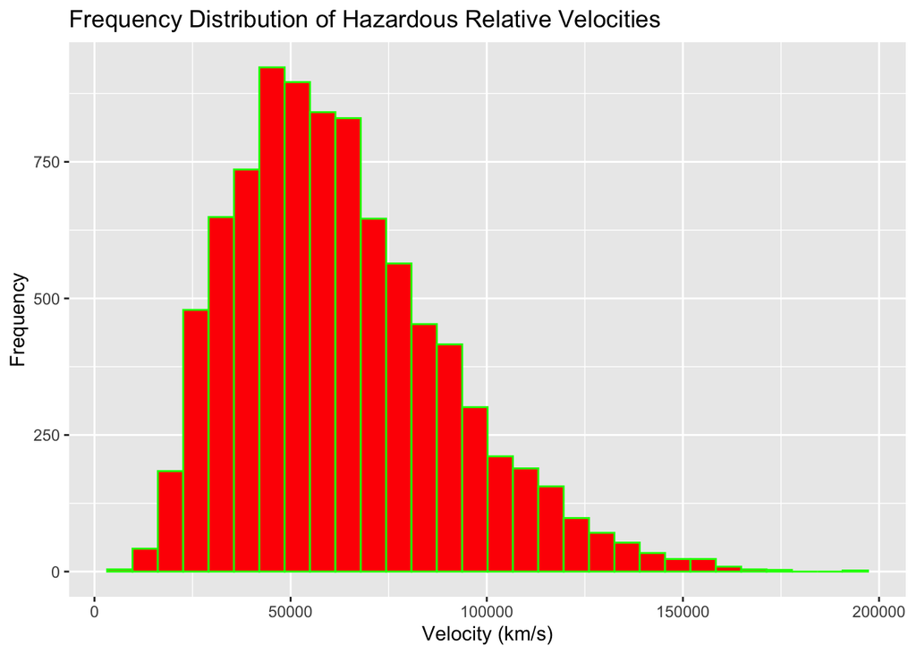

```r
ggplot(data=hazardous, aes(relative_velocity)) + geom_histogram(col='green',fill="red")+labs(x= "Velocity (km/s)", y="Frequency") + labs(title="Frequency Distribution of Hazardous Relative Velocities")
```

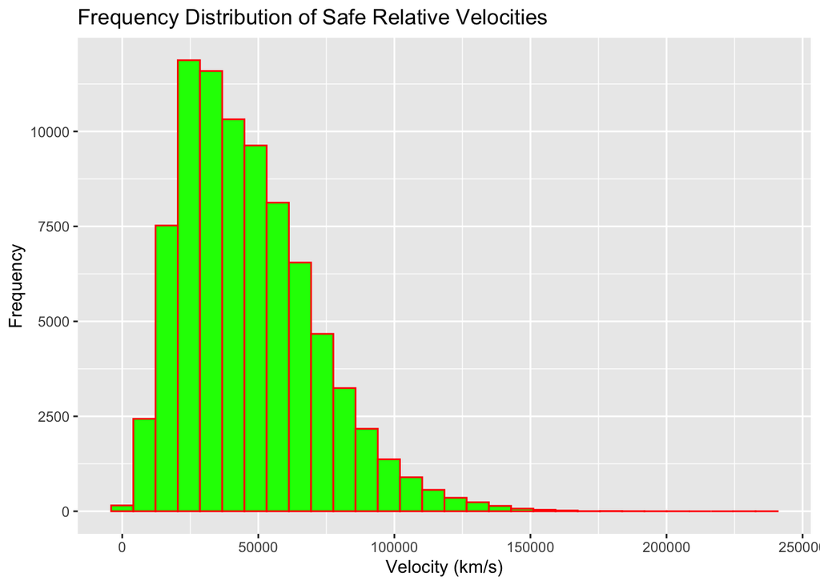

```r
ggplot(data=safe, aes(relative_velocity)) + geom_histogram(col='red',fill="green")+labs(x= "Velocity (km/s)", y="Frequency") + labs(title="Frequency Distribution of Safe Relative Velocities")
```

```r
velocity_outlier = outlierKD2(hazardous,relative_velocity, rm=TRUE)
```

```
## Outliers identified: 153
## Proportion (%) of outliers: 1.8
## Mean of the outliers: 145497
## Mean without removing outliers: 62794
## Mean if we remove outliers: 61338
## Outliers successfully removed
```

```r
safe_outlier = outlierKD2(safe,relative_velocity, rm=TRUE)
```

[figure not shown]

[figure not shown]

```
## Outliers identified: 1367
## Proportion (%) of outliers: 1.7
## Mean of the outliers: 126135
## Mean without removing outliers: 46479
## Mean if we remove outliers: 45129
## Outliers successfully removed
```

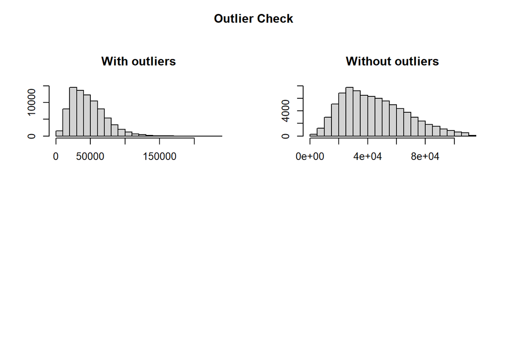

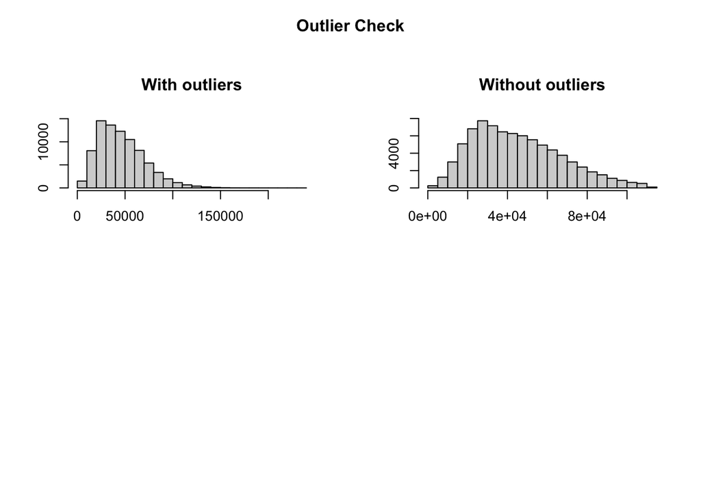

Relative velocity is one of the observable characteristics of the Kaggle dataset that other researchers in the field have looked at previously (Araujo 2014). Their research sought to identify the frequency of that asteroids would cross into potentially critical radii (“close encounters”) and, alongside impact parameter, relative velocity was one of the components the researchers examined. The researchers also used histograms to showcase the relative velocity component of their exploratory data analysis. With just a brief glance, the histograms clearly show that asteroids of the Atens groups suffered encounters with a higher relative velocity compared to the Amor group. Their overall findings were similar to ours, with asteroids and their satellites having a higher relative velocity representing the greatest probability of surviving the critical radii in the close encounter.

To estimate an asteroid’s destructive damage to Earth and her human-built infrastructure, we have baseline comparisons (as horrible as it is) in the area of high-yield nuclear weapons. To approximate asteroid impact energy as comparable to the yield of a high-explosive weapon in the megaton range, we would need to know the asteroid mass. Basic physics kinematics states that kinetic energy is a function of mass and velocity squared, KE= ½ MV^2. A one megaton explosion measures the explosive energy of one million tons of TNT, Trinitrotoluene, and is 4.18x10^15 Joules (Krehl 2008). The atomic bomb that dropped on Hiroshima was only 15 kilotons. Asteroids would yield easily in the megatons (Tonry 2010). Research on the former also requires mass to finalize the estimate of energy, and the scientists have a method to derive mass via density (usually taken as ∼2–3 g cm-3). They use the information to estimate the destructive capacity, as well as proposing early warning detection systems using what they know about asteroid destructive impact. Our work would equally benefit if we had asteroid mass (or a way to derive it).